# cw3

Dawid Dabkowski

14.03.2017

```r
library(rmarkdown)
library(PBImisc)
library(dplyr)
```

Stworzymy tabele, w ktorej wystepuje liniowa zaleznosc miedzy efektami w wierszach i kolumnach. Zobaczymy, czy wystepuje efekt interackji. Zakładamy również, że układ jest zrównoważony.

```r
A <- factor(rep(c(1,2,3,1,2,3), each=30))
B <- factor(rep(1:2, each=90))

C <- c(rep(10, 30), rep(20,30), rep(0,30), rep(15,30), rep(25,30), rep(5,30))
frame1 <- data.frame(A, B, C)
unclass(by(frame1[,3], frame1[,c(1,2)], mean))
```

```
##    B
## A    1  2
##   1 10 15
##   2 20 25
##   3  0  5
## attr(,"call")
## by.default(data = frame1[, 3], INDICES = frame1[, c(1, 2)], FUN = mean)
```

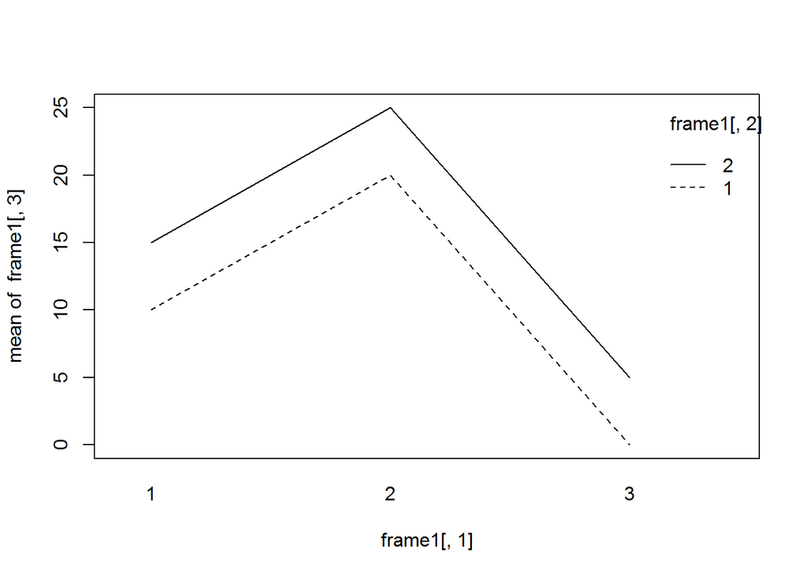

```r
interaction.plot(frame1[,1], frame1[,2], frame1[,3])
```

```r
a1 <- anova(lm(C~A*B, frame1))
a1["A:B","Pr(>F)"]
```

```
## [1] 0.4467304
```

Oczywiscie efektu interakcji nie ma. Pokazuje to zarowno wykres interakcji jak i wartosc testu F powyzej poziomu istotnosci.

Zobaczmy w takim razie czy zajdzie efekt interakcji dla układu zrównoważonego ale przy losowo zaburzonych danych. Doswiadczenie powtorzymy wiele razy i zbadamy ile razy wystapila interakcja dla testu na poziomie istotnosci 0.05.

```r
m <- 1000

test.frame1 <- function(n=0) {
  p <- c()
  for (i in 1:m) {
    C <- c(rnorm(30+n, mean=10), rnorm(30, mean=20), rnorm(30, mean=0), rnorm(30-n, mean=15), rnorm(30, mean=25), rnorm(30, mean=5))
    frame <- data.frame(A, B, C)
    a <- anova(lm(C~A*B, frame))
    p[i] <- a["A:B","Pr(>F)"]
  }
  sum(p<0.05)
}

test.frame1()
```

```
## [1] 49
```

Jak widać dodanie zaburzenia nie powoduje powstania istotnych interakcji (liczba testow na poziomie istotnosci 0.05, ktore wykazaly interakcje jest na poziomie 5% wszystkich testow).

Sprawdzmy jeszcze co sie stanie, jesli dodatkowo zrezygnujemy z rownolicznosci grup. Zwiekszmy liczebnosc jednej grupy o n kosztem drugiej i wykonajmy testy. Narysujmy wykres ilosci testow, ktore wykryly interakcje, w zaleznosci od n.

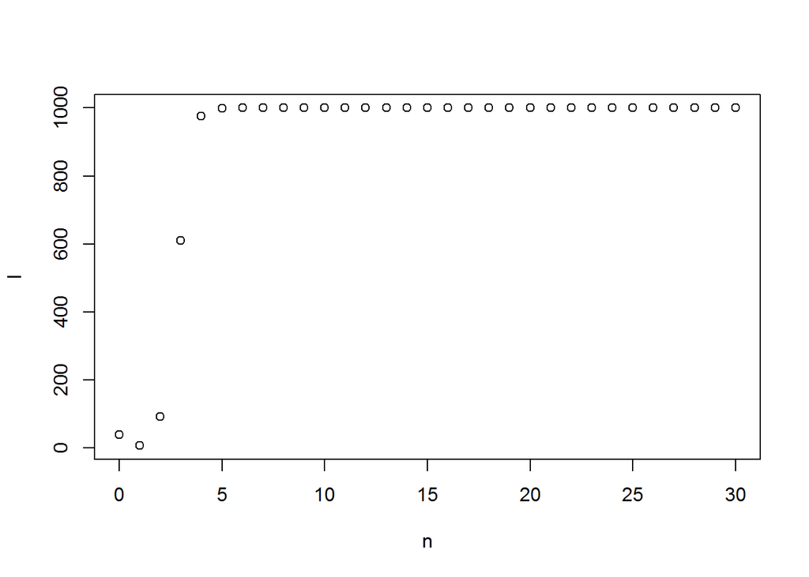

```r
n <- 0:30
l <- lapply(n, test.frame1)
plot(n, l)
```

Okazuje sie, ze juz dla niewielkiej zmiany (okolo n=4 czyli zaburzenie dwoch grup o okolo 13% poczatkowej liczebnosci) praktycznie wszystkie testy wykazuja interakcje.

Dzieje sie tak dlatego, ze test jest skonstruowany przy zalozeniu układu zrównoważonego.

Wykonajmy teraz podobne operacje dla tabeli, w ktorej nie ma liniowej zaleznosci miedzy efektami a wartoscia.

```r
A <- factor(rep(c(1,2,1,2), each=30))
B <- factor(rep(1:2, each=60))

C <- c(rep(10, 30), rep(0, 30), rep(20, 30), rep(30, 30))
frame2 <- data.frame(A, B, C)
unclass(by(frame2[,3], frame2[,c(1,2)], mean))
```

```
##    B
## A    1  2
##   1 10 20
##   2  0 30
## attr(,"call")
## by.default(data = frame2[, 3], INDICES = frame2[, c(1, 2)], FUN = mean)
```

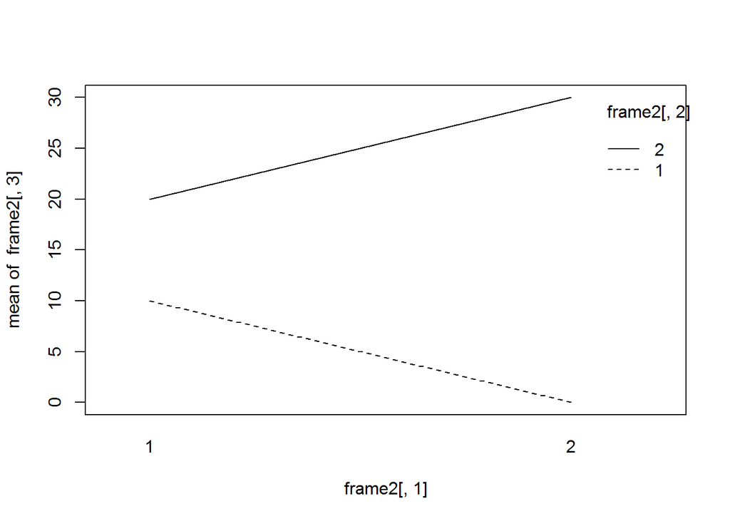

```r
interaction.plot(frame2[,1], frame2[,2], frame2[,3])
```

```r
a1 <- anova(lm(C~A*B, frame2))
a1["A:B","Pr(>F)"]
```

```
## [1] 0
```

Tak jak sie spodziewalismy, nierownolegle linie wykresu i test F ponizej poziomu istotnosci stwierdzaja mocno wystepowanie interakcji.

Tak jak poprzednio, zaburzymy dane czynnikiem losowym i powtorzymy eksperyment wiele razy. Sprawdzimy, ile testow wykaze interakcje.

```r
m <- 1000

test.frame2 <- function(n=0) {
  p <- c()
  for (i in 1:m) {
    C <- c(rnorm(30+n, mean=10), rnorm(30, mean=0), rnorm(30-n, mean=20), rnorm(30, mean=30))
    frame <- data.frame(A, B, C)
    a <- anova(lm(C~A*B, frame))
    p[i] <- a["A:B","Pr(>F)"]
  }
  sum(p<0.05)
}

test.frame2()
```

```
## [1] 1000
```

Pomimo zaburzenia praktycznie wszystkie testy wskazuja na interakcje.

Zobaczmy jeszcze, jak na testy wplynie zmiana liczebnosci grup. Podobnie jak poprzednio przelozymy n obserwacji z jednej grupy do innej.

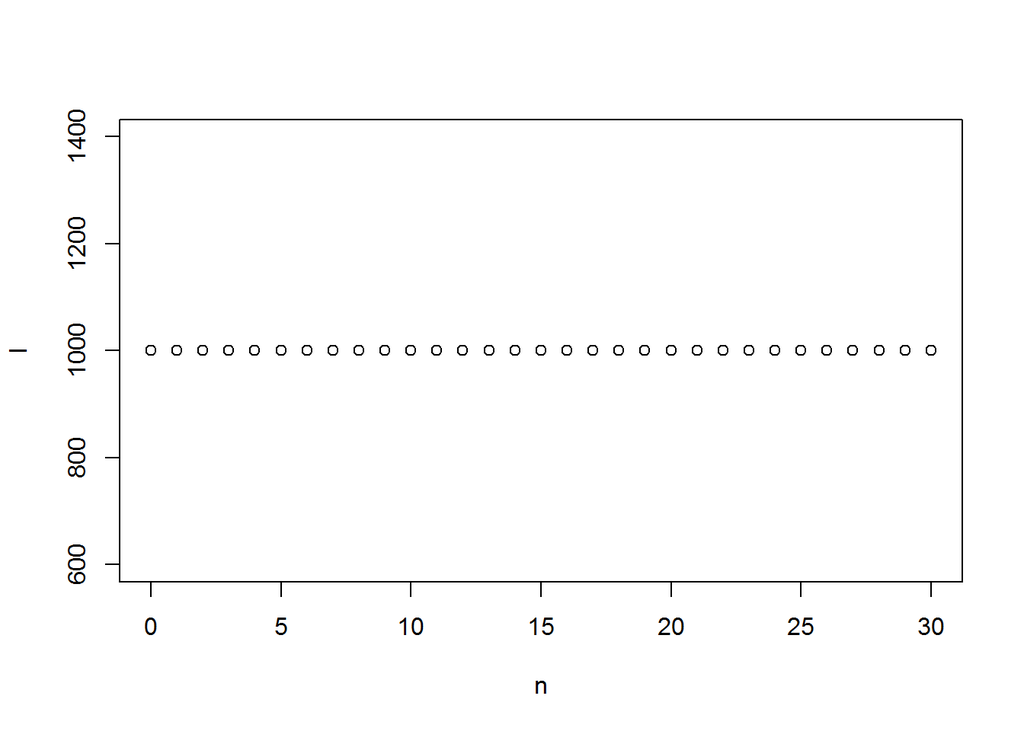

```r
n <- 0:30
l <- lapply(n, test.frame2)
plot(n, l)
```

Ten niezbyt fascynujacy wykres pokazuje, ze zmiana liczebnosci grup takze nie wplynela na werdykt testu, ktory krzyczy, ze interakcje sa obecne.

Podsumowujac, dodanie zaburzenia losowego nie wplywa istotnie na test hipotezy, ze nie ma interakcji. Moze to swiadczyc o tym, ze test ten jest dobrze skonstruowany. Z kolei brak zrównoważenia układu nie jest przewidziany w tescie F i nie powinno sie w ten sposob badac zachodzenia interakcji. Ogromne zaklocenie pojawia sie juz przy niewielkiej modyfikacji liczności grup.